# Lab 4

Ryan Pate

3/17/2021

Cleaning

1. Player and opponent names as factors.

   ```r
   defense <- read_excel('/Users/ryanpate/Downloads/cyclonesFootball2020.xlsx', sheet='Defensive')
   offensive <- read_excel('/Users/ryanpate/Downloads/cyclonesFootball2020.xlsx', sheet='Offensive')
   biography <- read_excel('/Users/ryanpate/Downloads/cyclonesFootball2020.xlsx', sheet='Biography')

   defense$Opponent_Opponent <- as.factor(defense$Opponent_Opponent)
   defense$Name <- as.factor(defense$Name)
   biography$Name <- as.factor(biography$Name)
   offensive$Name <- as.factor(offensive$Name)
   offensive$Opponent_Opponent <- as.factor(offensive$Opponent_Opponent)
   ```

2. Stats as numeric. `Weight` as numeric.

   ```r
   defense$Tackles_Solo <- as.numeric(defense$Tackles_Solo)
   defense$Tackles_ASST <- as.numeric(defense$Tackles_ASST)
   defense$Tackles_TFL <- as.numeric(defense$Tackles_TFL)
   defense$Tackles_Sack <- as.numeric(defense$Tackles_Sack)
   defense$Turnover_FF <- as.numeric(defense$Turnover_FF)
   defense$Turnover_FR <- as.numeric(defense$Turnover_FR)
   defense$Turnover_INT <- as.numeric(defense$Turnover_INT)
   defense$Pass_QBH <- as.numeric(defense$Pass_QBH)
   defense$Pass_PB <- as.numeric(defense$Pass_PB)

   defClean <- defense

   names(offensive)[names(offensive) == "Passing_CMP-ATT"] <- "Passing_CMP"

   offensive$Receiving_REC <- as.numeric(offensive$Receiving_REC)
   offensive$Receiving_YDS <- as.numeric(offensive$Receiving_YDS)
   offensive$Receiving_TD <- as.numeric(offensive$Receiving_TD)
   offensive$Rushing_ATT <- as.numeric(offensive$Rushing_ATT)
   offensive$Rushing_YDS <- as.numeric(offensive$Rushing_YDS)
   offensive$Rushing_TD <- as.numeric(offensive$Rushing_TD)
   offensive$Passing_CMP <- as.numeric(offensive$Passing_CMP)
   ```

   ```r
   offensive$Passing_YDS <- as.numeric(offensive$Passing_YDS)
   offensive$Passing_TD <- as.numeric(offensive$Passing_TD)
   offensive$Passing_INT <- as.numeric(offensive$Passing_INT)

   offClean <- offensive

   biography$Weight <- as.numeric(biography$Weight)
   ```

3. `Height` as numeric.

   ```r
   bioClean <- biography %>%
   separate(Height, c('feet', 'inches'), sep='-', convert=TRUE, remove=FALSE) %>%
   mutate(height = 12*feet + inches) %>%
   select(-Height) %>%
   select(-feet) %>%
   select(-inches)
   ```

   ```r
   str(bioClean)
   ```

   ```
   ## tibble [116 × 7] (S3: tbl_df/tbl/data.frame)
   ##  $ Name      : Factor w/ 116 levels "Akers, Landen",..: 1 2 3 4 5 6 7 8 9 10 ...
   ##  $ Position  : chr [1:116] "Wide Receiver" "Tight End" "Wide Receiver" "Defensive Back" ...
   ##  $ Weight    : num [1:116] 191 240 208 180 195 199 253 261 288 182 ...
   ##  $ Class     : chr [1:116] "Redshirt Senior" "Redshirt Senior" "Redshirt Freshman" "Freshman" ...
   ##  $ Hometown  : chr [1:116] "Cedar Rapids, Iowa" "Nixa, Mo." "Seffner, Fla." "Ft. Lauderdale, Fla." ...
   ##  $ Highschool: chr [1:116] "Washington" "Nixa" "Armwood" "Cardinal Gibbons" ...
   ##  $ height    : num [1:116] 72 79 77 72 72 72 75 74 74 74 ...
   ```

   ```r
   str(defClean)
   ```

   ```
   ## tibble [372 × 11] (S3: tbl_df/tbl/data.frame)
   ##  $ Name             : Factor w/ 37 levels "Akers, Landen",..: 26 26 26 26 26 26 26 26 26 26 ...
   ##  $ Opponent_Opponent: Factor w/ 11 levels "Baylor","Kansas",..: 4 8 5 10 6 2 1 3 9 11 ...
   ##  $ Tackles_Solo     : num [1:372] 2 6 6 3 7 4 7 4 4 2 ...
   ##  $ Tackles_ASST     : num [1:372] 4 4 5 0 3 1 4 3 9 3 ...
   ##  $ Tackles_TFL      : num [1:372] 1 0 1.5 1 1 0 1.5 2.5 1.5 0 ...
   ##  $ Tackles_Sack     : num [1:372] 0 0 0.5 0 0 0 0 1 0 0 ...
   ##  $ Turnover_FF      : num [1:372] 0 0 0 0 0 0 0 0 0 0 ...
   ##  $ Turnover_FR      : num [1:372] 0 0 0 0 0 0 0 0 0 0 ...
   ##  $ Turnover_INT     : num [1:372] 0 1 0 0 1 0 1 1 0 0 ...
   ##  $ Pass_QBH         : num [1:372] 0 0 1 0 0 0 2 1 0 0 ...
   ##  $ Pass_PB          : num [1:372] 0 0 0 0 0 1 0 0 1 0 ...
   ```

   ```r
   str(offClean)
   ```

   ```
   ## tibble [156 × 12] (S3: tbl_df/tbl/data.frame)
   ##  $ Name             : Factor w/ 16 levels "Akers, Landen",..: 1 1 1 1 1 1 1 1 1 1 ...
   ##  $ Opponent_Opponent: Factor w/ 11 levels "Baylor","Kansas",..: 4 8 5 10 6 2 1 3 9 11 ...
   ##  $ Receiving_REC    : num [1:156] 0 2 1 4 0 6 1 0 1 1 ...
   ##  $ Receiving_YDS    : num [1:156] 0 60 35 34 0 76 11 0 10 2 ...
   ##  $ Receiving_TD     : num [1:156] 0 0 0 0 0 0 0 0 0 1 ...
   ##  $ Rushing_ATT      : num [1:156] NA NA NA NA NA NA NA NA NA NA ...
   ##  $ Rushing_YDS      : num [1:156] NA NA NA NA NA NA NA NA NA NA ...
   ##  $ Rushing_TD       : num [1:156] NA NA NA NA NA NA NA NA NA NA ...
   ##  $ Passing_CMP      : num [1:156] NA NA NA NA NA NA NA NA NA NA ...
   ##  $ Passing_YDS      : num [1:156] NA NA NA NA NA NA NA NA NA NA ...
   ##  $ Passing_TD       : num [1:156] NA NA NA NA NA NA NA NA NA NA ...
   ##  $ Passing_INT      : num [1:156] NA NA NA NA NA NA NA NA NA NA ...
   ```

Tidying

1. Reformat the `offClean` data frame into a tidy format using `pivot_longer`. The type of statistic (Receiving_REC for the number of receivings, Receiving_YDS for receiving yards, etc) is added as a new key column named `stat`.

   ```r
   offClean <- offClean %>%
   pivot_longer(c('Receiving_REC', 'Receiving_YDS', 'Receiving_TD', 'Rushing_ATT', 'Rushing_YDS', 'Rushing_TD',        'Passing_CMP', 'Passing_YDS', 'Passing_TD', 'Passing_INT'),
              names_to = "stat", values_to = "count")

   str(offClean)
   ```

   ```
   ## tibble [1,560 × 4] (S3: tbl_df/tbl/data.frame)
   ##  $ Name             : Factor w/ 16 levels "Akers, Landen",..: 1 1 1 1 1 1 1 1 1 1 ...
   ##  $ Opponent_Opponent: Factor w/ 11 levels "Baylor","Kansas",..: 4 4 4 4 4 4 4 4 4 4 ...
   ##  $ stat             : chr [1:1560] "Receiving_REC" "Receiving_YDS" "Receiving_TD" "Rushing_ATT" ...
   ##  $ count            : num [1:1560] 0 0 0 NA NA NA NA NA NA NA ...
   ```

2. Show on the distributions of the offensive statistics. The distribution of each offensive statistic should be shown in a separate facet. Explain the patterns you see.

   Yards are disproportionally the most numerous in every event.

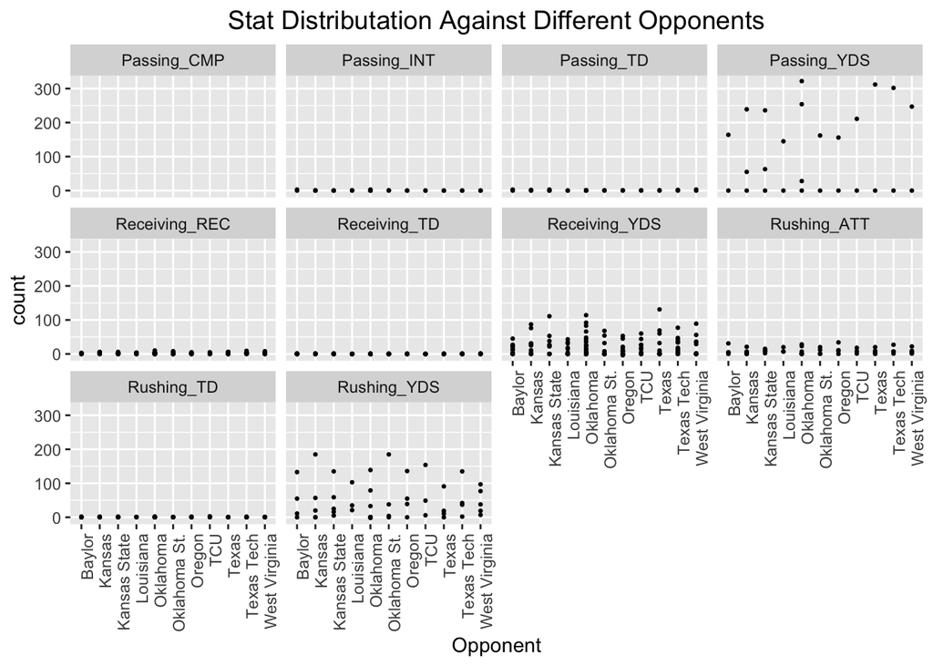

   ```r
   ggplot(offClean, aes(x=Opponent_Opponent, y=count)) + geom_point(size=0.5) + facet_wrap(~stat) +
     theme(axis.text.x = element_text(angle=90, hjust=1)) +
     labs(title="Stat Distributation Against Different Opponents", x="Opponent") +
     theme(plot.title = element_text(size=14, hjust=0.5))
   ```

3. Did ISU have better offense against Oregon or Oklahoma? Answer this question by creating a scatterplot with the x- and y-axes being the receiving yards of the ISU players against these two opponents. A large number of receiving yards indicates good offense.

   I was not able to separate the opponent data to graph the performance vs Oregan with the performance vs Oklahoma. My first try was to subset them, but as far as I know you cannot graph two datasets in one plot the way I was trying to. I also tried to use `pivot_wider` but the data would not translate properly.
4. Separate the `Hometown` column into two columns, namely, the city and the state where the player comes from. Print the first few rows of these two columns. (Hint: look at the sep= argument of separate)

   ```r
   bioClean <- bioClean %>%
     separate(Hometown, c('city', 'state'), sep=',', convert=TRUE, remove=FALSE)
   head(bioClean$city)
   ```

   ```
   ## [1] "Cedar Rapids"   "Nixa"           "Seffner"        "Ft. Lauderdale"
   ## [5] "Naperville"     "Grand Prairie"
   ```

   ```r
   head(bioClean$state)
   ```

   ```
   ## [1] " Iowa"  " Mo."   " Fla."  " Fla."  " Ill."  " Texas"
   ```

5. How many players are there from each state?

   ```r
   statenum <- count(bioClean, state)
   statenum
   ```

   ```
   ## # A tibble: 21 x 2
   ##    state            n
   ##    <chr>        <int>
   ##  1 " Ariz."         4
   ##  2 " Ark."          1
   ##  3 " Australia"     1
   ##  4 " Calif."        2
   ##  5 " Fla."         14
   ##  6 " Ga."           3
   ##  7 " Ill."          6
   ##  8 " Iowa"         42
   ##  9 " Kan."          4
   ## 10 " Mich"          1
   ## # … with 11 more rows
   ```

Joining data frames

1. Find which states do the ISU players (both defensive and offensive) come from. Create an appropriate numerical or graphical summary.

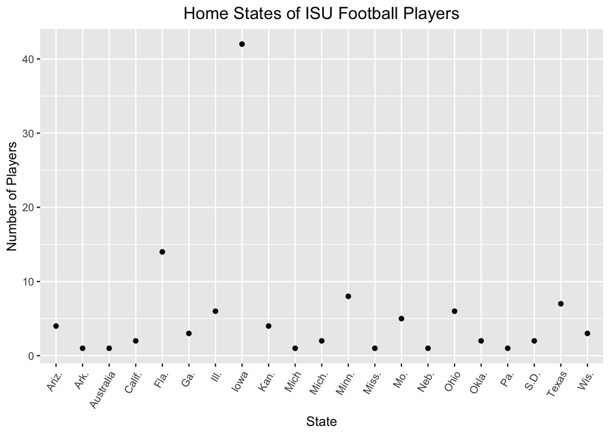

   ```r
   ggplot(statenum, aes(x = state, y = n)) + geom_point() + labs(title="Home States of ISU Football Players", y="Number of Players", x="State") +
     theme(axis.text.x = element_text(angle=60, hjust=1)) + theme(plot.title = element_text(size=14, hjust=0.5))
   ```

2. How does the performance of quarterback Brock Purdy relate to the performance of the ISU team?

   Purdy consistently has significantly more passing yards than other ISU players.
3. Which ISU player(s) made the biggest progress over the last year? Compare the player-level statistics (i.e. averages and totals for each player) using both the 2020 and the 2019 data here. Choose for yourself the player statistics to investigate.

   ```r
   offense2019 <- read_excel('/Users/ryanpate/Downloads/cyclonesFootball2019.xlsx', sheet='Offensive')

   offense2019$Name <- as.factor(offense2019$Name)
   offense2019$Opponent_Opponent <- as.factor(offense2019$Opponent_Opponent)

   names(offense2019)[names(offense2019) == "Passing_CMP-ATT"] <- "Passing_CMP"

   offense2019$Receiving_REC <- as.numeric(offense2019$Receiving_REC)
   offense2019$Receiving_YDS <- as.numeric(offense2019$Receiving_YDS)
   offense2019$Receiving_TD <- as.numeric(offense2019$Receiving_TD)
   offense2019$Rushing_ATT <- as.numeric(offense2019$Rushing_ATT)
   offense2019$Rushing_YDS <- as.numeric(offense2019$Rushing_YDS)
   offense2019$Rushing_TD <- as.numeric(offense2019$Rushing_TD)
   offense2019$Passing_CMP <- as.numeric(offense2019$Passing_CMP)
   offense2019$Passing_YDS <- as.numeric(offense2019$Passing_YDS)
   offense2019$Passing_TD <- as.numeric(offense2019$Passing_TD)
   offense2019$Passing_INT <- as.numeric(offense2019$Passing_INT)

   clean2019 <- offense2019 %>%
     pivot_longer(c('Receiving_REC', 'Receiving_YDS', 'Receiving_TD', 'Rushing_ATT', 'Rushing_YDS', 'Rushing_TD', 'Passing_CMP', 'Passing_YDS', 'Passing_TD', 'Passing_INT'),
              names_to = "stat", values_to = "count")
   ```